Sesión 4

[figure not shown]

Visión Artificial · Posgrado

# Sesión 4 — Características locales: SIFT y la familia de descriptores

**SIFT** · ORB · SURF · BRISK · KAZE/AKAZE  
Detección, descripción y emparejamiento (matching) de puntos de interés  
**Dr. Víctor Alejandro González Huitrón** · Instituto Tecnológico de Querétaro

01

Motivación

# ¿Por qué necesitamos "características locales"?

De esquinas (Harris) a descriptores invariantes a escala y rotación.

## El problema: emparejar la misma escena bajo cambios

- Harris detecta **esquinas**, pero no es invariante a **escala**: una esquina vista de cerca es una curva vista de lejos.
- Para reconocer objetos, hacer **stitching** de panorámicas, **SLAM** o recuperar pose 3D necesitamos puntos que se detecten **igual** aunque cambie escala, rotación, iluminación o punto de vista.
- La solución: un **detector** (dónde) + un **descriptor** (cómo se ve alrededor) que sean repetibles y distintivos.

Detección = *encontrar* el punto. Descripción = *codificar* su vecindad en un vector comparable entre imágenes.

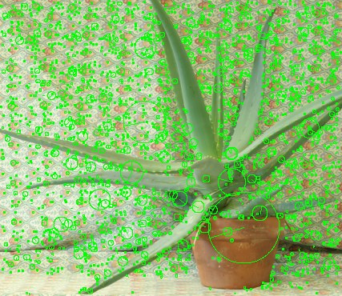

Keypoints SIFT: posición, escala (radio del círculo) y orientación

02

Algoritmo clásico

# SIFT — Scale Invariant Feature Transform

Lowe, 1999/2004. El descriptor que definió dos décadas de visión.

## ¿Qué es SIFT?

SIFT detecta **keypoints** a partir de una representación **multiescala**. Cada keypoint queda descrito por **(x, y, σ, θ)**: centro, escala y orientación dominante — definiendo el centro, tamaño y orientación de una plantilla en teoría invariante a traslación, rotación y escala.

El descriptor codifica la distribución del gradiente alrededor del punto en un vector de **128 valores**, usado para comparar keypoints entre imágenes.

Ese vector de 128-D es un "embedding" hecho a mano. Las CNN modernas aprenden embeddings equivalentes (p. ej. SuperPoint, LoFTR) desde datos en vez de diseñarlos a mano.

## Las 6 etapas del algoritmo

1. **Espacio de escala gaussiano** — banco de imágenes suavizadas con σ creciente.
2. **Aproximación del LoG mediante DoG** — Diferencia de Gaussianos, filtro pasabanda de bajo costo.
3. **Determinación de keypoints** — extremos (máx/mín) en el espacio (x, y, σ).
4. **Reducción de keypoints** — descarta bajo contraste y bordes; conserva esquinas (criterio tipo Harris).
5. **Asignación de orientación** — histograma de gradientes → θ dominante (invarianza rotacional).
6. **Generación del descriptor** — vector de 128 valores por keypoint.

## 1 · Espacio de escala gaussiana

Banco de imágenes con emborronamiento gaussiano creciente, simulando alejar la escena. El factor de emborronamiento es **σ**.

[figure not shown]

Se organiza en **octavas** (se reduce la imagen a la mitad) con varias escalas por octava. Buscar en todas las escalas = invarianza a escala.

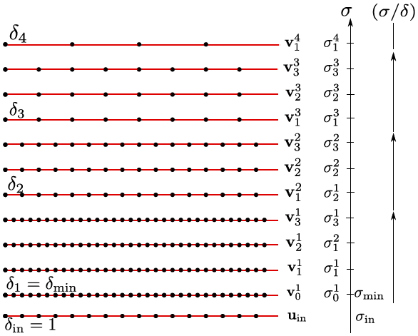

## 2 · Aproximación del LoG con DoG

El ideal para detectar puntos de interés son los extremos del **Laplaciano del Gaussiano (LoG)**, pero es costoso. SIFT usa la **Diferencia de Gaussianos (DoG)**, que actúa como **filtro pasabanda**: conserva los detalles relevantes.

[figure not shown]

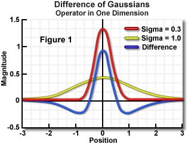

DoG (azul) aproxima al LoG: respuesta pasabanda

## 2 · DoG sobre imagen real

[figure not shown]

Resultado del filtro DoG: resalta bordes y estructura a la escala seleccionada

## 3 · Determinación de keypoints

Dos pasos:

1. Detectar mín/máx de intensidad a nivel píxel comparando contra sus **26 vecinos** (8 en la escala + 9 arriba + 9 abajo).
2. **Interpolación cuadrática** para la posición final con precisión sub-píxel y sub-escala.

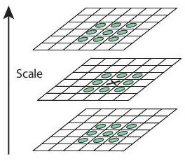

Comparación con los 26 vecinos en escalas adyacentes

## 3 · Extremos e interpolación sub-píxel

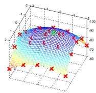

Ajuste cuadrático del extremo en el espacio-escala para localización precisa

## 4 · Reducción de keypoints

Se calculan gradientes horizontal y vertical y se descartan:

- Puntos en **regiones lisas / bajo contraste** (umbral sobre las imágenes DoG).
- **Bordes** (mal localizados a lo largo de la línea).
- Se conserva solo lo detectado como **esquina**, con un criterio similar al detector **Harris** (razón de curvaturas principales / Hessiana).

Aquí reaparece Harris de la sesión 3: SIFT filtra sus candidatos con la misma idea de "esquina = dos curvaturas fuertes".

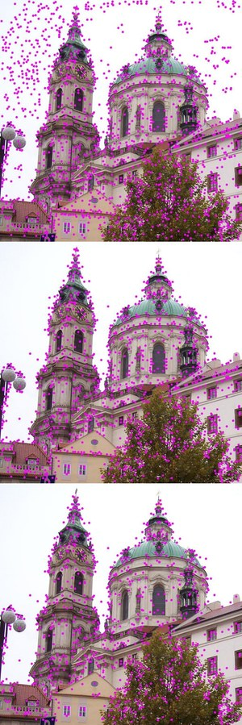

## 5 · Asignación de orientación

Alrededor del keypoint se calcula un **histograma de orientaciones** del gradiente (36 bins, 10° c/u), ponderado por magnitud y una ventana gaussiana.

- El pico dominante define **θ**.
- Picos secundarios ≥ 80% del máximo → keypoints adicionales.
- El descriptor se mide **relativo a θ** → invarianza a rotación.

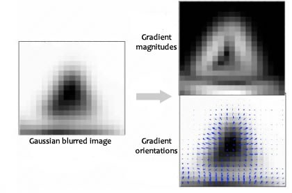

Magnitud y orientación del gradiente en la vecindad

## 5 · Histograma de orientaciones

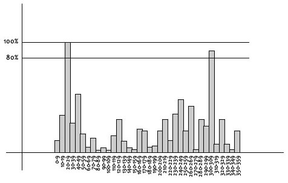

Histograma de 36 bins: el pico marca la orientación dominante θ

## 6 · El descriptor de 128 valores

Ventana de **16×16** alrededor del keypoint (ya rotada a θ), dividida en **4×4** subregiones. En cada una, un histograma de **8 orientaciones**.

[figure not shown]

Se normaliza (robustez a iluminación), se recorta a 0.2 y se re-normaliza (robustez a saturación).

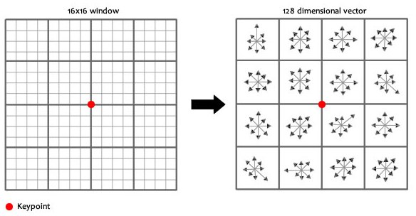

16×16 → vector de 128 dimensiones

## 6 · El descriptor en acción

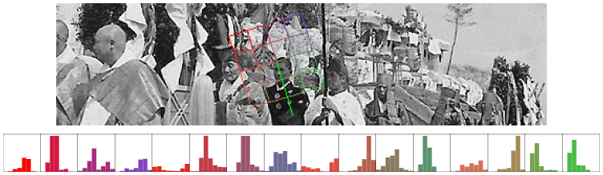

Distribución espacial del gradiente codificada como el vector de características por keypoint

## Ponderación gaussiana del descriptor

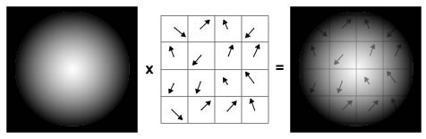

Los gradientes se pesan por una gaussiana centrada: los cercanos al keypoint pesan más

Esta ponderación por cercanía es la misma intuición del *self-attention*: no todos los elementos del vecindario contribuyen igual.

03

Alternativas

# La familia: ORB, SURF, BRISK, KAZE/AKAZE

Por qué existen tantos algoritmos que "hacen lo mismo".

## Historia: la patente que creó una industria de alternativas

SIFT estuvo **patentado** (US 6,711,293, Universidad de British Columbia, David Lowe). La solicitud provisional se presentó en **marzo de 1999** y la patente **expiró el 6–7 de marzo de 2020**.

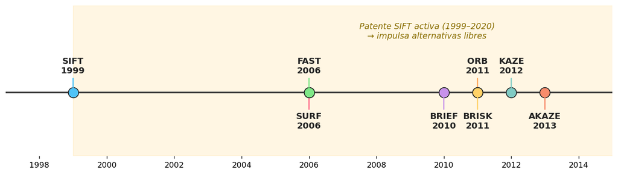

Mientras SIFT (y SURF) requerían licencia comercial, la comunidad creó alternativas **libres**: ORB, BRISK, KAZE/AKAZE. Por eso hay varias que parecen hacer lo mismo — nacieron para esquivar la patente sin perder desempeño.

## ¿En qué se parecen? El esqueleto común

Casi todos comparten la misma receta de dos fases:

**Detector** — encuentra puntos repetibles

- SIFT/SURF/KAZE: extremos en espacio-escala (blob).
- ORB: esquinas **FAST** + pirámide para escala.
- BRISK/AKAZE: FAST/AGAST sobre espacio-escala.

**Descriptor** — codifica la vecindad

- SIFT/SURF/KAZE: vector **flotante** (histogramas de gradiente).
- ORB/BRISK/AKAZE: cadena **binaria** (comparaciones de intensidad, tipo BRIEF).

La gran divisoria es el **tipo de descriptor**: flotante (distancia L2) vs binario (distancia de Hamming).

## La diferencia clave: flotante vs binario

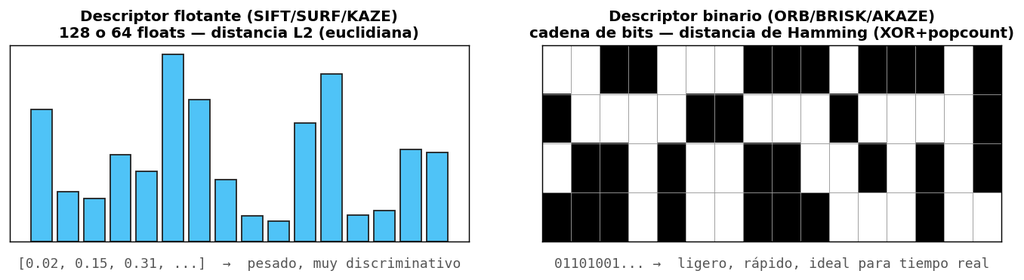

**Flotante**: más discriminativo, más pesado. Matching con **L2** + FLANN (KD-tree).

**Binario**: compacto y rapidísimo. Matching con **Hamming** (XOR + popcount) + LSH.

## Tabla comparativa

| Algoritmo | Año | Descriptor | Distancia | Velocidad | Invarianza | Licencia |
| --- | --- | --- | --- | --- | --- | --- |
| **SIFT** | 1999 | 128 float | L2 | Lenta | Escala, rot., ilum. (muy robusto) | Libre desde 2020 |
| **SURF** | 2006 | 64/128 float | L2 | Media (usa img. integral) | Escala, rot. | Patentado |
| **ORB** | 2011 | 256 bits | Hamming | Muy rápida | Rot. + escala (pirámide) | Libre (BSD) |
| **BRISK** | 2011 | 512 bits | Hamming | Rápida | Escala, rot. | Libre |
| **KAZE** | 2012 | 64/128 float | L2 | Lenta | Escala, rot. (bordes nítidos) | Libre (BSD) |
| **AKAZE** | 2013 | 486 bits (MLDB) | Hamming | Rápida | Escala, rot. | Libre (BSD) |

KAZE/AKAZE usan **difusión no lineal** en vez de gaussiano: respetan mejor los bordes (no los emborronan al construir la escala).

## ¿Cuál uso y cuándo?

| Situación | Recomendación | Por qué |
| --- | --- | --- |
| Máxima precisión, offline (SfM, calibración, registro médico) | **SIFT** | El más robusto y repetible; el costo no importa si no es en vivo. |
| Tiempo real / embebido (SLAM, AR, móvil, ARM) | **ORB** / **AKAZE** | Binarios, ligeros, matching por Hamming muy veloz. |
| Texturas finas y bordes, sin patente | **KAZE/AKAZE** | La difusión no lineal preserva detalle en fronteras. |
| Producto comercial | Evitar **SURF** | Sigue patentado; preferir ORB/BRISK/AKAZE (o SIFT ya libre). |
| Punto de partida por defecto | **ORB** | Gratis, rápido, incluido en OpenCV core, buen balance. |

04

Manos a la obra